# PATH analysis of glioblastoma

```r
library(PATH)
library(expm)
library(ggplot2)
library(ggtree)
library(ggtreeExtra)
library(tidytree)
library(Matrix)
library(patchwork)
library(parallel)
library(msigdbr)
library(magrittr)
library(tidyverse)
library(fgsea)
```

### Introduction

In this vignette we demonstrate how to use PATH to analyze a human derived glioblastoma (GBM) patient sample. For this sample we load the tumor phylogeny, and per cell matrices of gene expression (from scRNAseq), and module scores for previously defined GBM gene sets.

Specifically, we quantify the heritability of four previously defined GBM gene modules: Neural Progenitor-like (NPC), Oligodendrocyte Progenitor-like (OPC), Astrocyte-like (AC), and Mesenchymal-like (MES) expression, by measuring phylogenetic auto-correlations. Next, we measure the phylogenetic cross-correlations between GBM gene modules to understand how they might be evolutionarily related.

Afterwards, we classify cells into distinct states or cell types based on their GBM gene module scores, and use PATH to infer the transition probabilities connecting cell types.

Finally, looking beyond the analysis of previously defined GBM gene modules, we use PATH to measure and then rank the heritability of the most variably expressed genes (in this sample) to search for heritable gene modules in an unbiased manner.

### Data

This vignette uses three RDS objects stored in this repository:

- `tree115`, the GBM phylogenetic tree from patient MGH115,
- `modules115`, GBM gene modules. Rows represent cells, and columns, module scores, and
- `genes115`, gene expression of the 3,000 most variably expressed genes.

These can be previewed, as directly below.

```r
# GBM patient phylogenetic tree
tree115
```

```
#>
#> Phylogenetic tree with 38 tips and 37 internal nodes.
#>
#> Tip labels:
#>   S2_ACAACC, S4_CCATAG, S2_ATCAAG, S2_CAAGAG, S3_CTCAGC, S3_CGGTAG, ...
#>
#> Rooted; includes branch lengths.
```

```r
# per-cell GBM gene modules
modules115 %>% as_tibble()
```

```
#> # A tibble: 38 × 4
#>        NPC    OPC     AC     MES
#>      <dbl>  <dbl>  <dbl>   <dbl>
#>  1 -0.885  -1.24  -2.11   0.279
#>  2 -0.619  -0.797 -0.275  0.0833
#>  3 -0.588  -1.33  -1.78   0.733
#>  4  0.492   0.576  0.895 -0.445
#>  5 -0.843  -0.946 -1.94   0.504
#>  6 -0.787  -1.12  -1.76   1.20
#>  7  0.0852  0.516  1.65  -0.0961
#>  8 -0.992  -1.26  -1.88   1.06
#>  9 -0.489  -0.698 -0.316  1.23
#> 10  0.0728  0.258  1.06  -0.136
#> # ℹ 28 more rows
```

```r
# per-cell gene expression
genes115 %>% as_tibble()
```

```
#> # A tibble: 38 × 3,000
#>     TSPAN6    CFH    GCLC   CFTR MAD1L1   M6PR   KLHL13   ICA1   TFPI NDUFAF7
#>      <dbl>  <dbl>   <dbl>  <dbl>  <dbl>  <dbl>    <dbl>  <dbl>  <dbl>   <dbl>
#>  1 -0.0979  1.41  -0.642  -0.240 -0.478 -1.08   1.43    -0.269 -0.721  -0.503
#>  2 -0.267  -0.202 -0.0783  0.489 -0.477 -1.08  -0.309    1.43  -0.172   1.11
#>  3  1.35   -0.203 -0.641  -0.238 -0.477 -0.668 -0.310   -0.267 -0.732  -0.611
#>  4  0.578  -0.203 -0.641  -0.238 -0.477  1.17  -0.309   -0.267  1.32   -0.611
#>  5 -0.762  -0.204  1.35   -0.239 -0.478 -1.08  -0.00961 -0.268  0.867   1.40
#>  6 -0.760  -0.198 -0.640  -0.234 -0.130  1.17  -0.306   -0.264 -0.730   0.356
#>  7  0.467  -0.204 -0.152  -0.238 -0.477 -0.346 -0.310   -0.268  1.32   -0.612
#>  8 -0.761  -0.200 -0.640  -0.235  1.40  -1.08  -0.308   -0.265  1.32   -0.514
#>  9  0.271  -0.205 -0.642   1.43   1.40  -0.887 -0.311    1.43   1.32   -0.612
#> 10 -0.762   1.06  -0.641  -0.239 -0.478 -1.02  -0.310    1.43   0.815  -0.612
#> # ℹ 28 more rows
#> # ℹ 2,990 more variables: FKBP4 <dbl>, RECQL <dbl>, VPS50 <dbl>,
#> #   SLC25A13 <dbl>, ST7 <dbl>, CDC27 <dbl>, CIAPIN1 <dbl>, MSL3 <dbl>,
#> #   WDR54 <dbl>, PDK2 <dbl>, ITGA3 <dbl>, GDE1 <dbl>, MAP3K14 <dbl>,
#> #   ABCC8 <dbl>, TMEM132A <dbl>, ZNF263 <dbl>, TNFRSF12A <dbl>, DBF4 <dbl>,
#> #   VPS41 <dbl>, CDKL3 <dbl>, TRAPPC6A <dbl>, PAX6 <dbl>, RHBDF1 <dbl>,
#> #   TSR3 <dbl>, PIGQ <dbl>, CYB561 <dbl>, CELSR3 <dbl>, MGST1 <dbl>, …
```

### GBM gene module heritability

First we use our framework to study the phylogenetic patterning of the four GBM gene modules (NPC, OPC, AC, and MES).

#### Gene module phylogenetic auto-correlations

To calculate phylogenetic correlations, we first need a phylogenetic weight matrix, which represents the relatedness of each cell in the phylogeny. Here we use a weight matrix that contains the inverse phylogenetic node distances between cells, by passing the GBM phylogeny `tree115` to the PATH function, `inv_tree_dist()`.

We can then measure the heritability of each GBM gene module, by using the PATH function `xcor()`, inputting the phylogenetic weight matrix calculated above, and our phenotype(s) of interest, here setting `data = modules115`.

Note that the `xcor()` function expects the class of the `data` argument to be a `matrix`, so phenotypes in the `data.frame` or `numeric` (for instance, if studying only one phenotype) classes need to be converted before using `xcor()`, with `as.matrix()`.

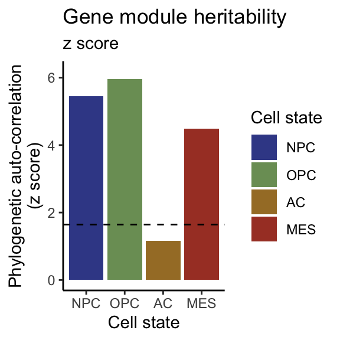

```r
# Compute the phylogenetic node distances between cells in order to measure phylogenetic correlations.
Winv <- inv_tree_dist(tree115, node = TRUE, norm = FALSE)

# Compute phylogenetic correlations between GBM modules.
modxcor <- xcor(modules115, Winv)

# Process xcor output for plotting and visualization.
Idf <- reshape2::melt(modxcor$phy_cor,
                      value.name = "I")
Zdf <- reshape2::melt(modxcor$Z.score,
                      value.name = "Z")

df <- full_join(Idf, Zdf, by=c("Var1", "Var2"))

df <- df %>% mutate(Var1 = as.factor(Var1),
                      Var2 = as.factor(Var2))

# Phylogenetic auto-correlation bar plot.

maxz <- max(abs(df$Z))
df %>%
  filter(Var1 == Var2) %>%
  ggplot(aes(x=Var1, y=Z, fill=Var1)) +
  geom_bar(stat="identity") +
  ylim(c(0,maxz)) +
  theme_classic() +
  #scale_fill_brewer(palette = "Set1", type = "div") +
  scale_fill_manual(values = gbm_state_colors) +
  labs(fill="Cell state") +
  ylab("Phylogenetic auto-correlation\n(z score)") +
  xlab("Cell state") +
  geom_hline(yintercept = qnorm(0.05, lower.tail = F),
             col="black", lty=2) +
  ggtitle("Gene module heritability",
          subtitle = "z score")
```

#### Gene module cross-correlations

We can further visualize the phylogenetic relationships between GBM gene modules by plotting their pairwise phylogenetic cross-correlations, included in the output from `xcor()` used above.

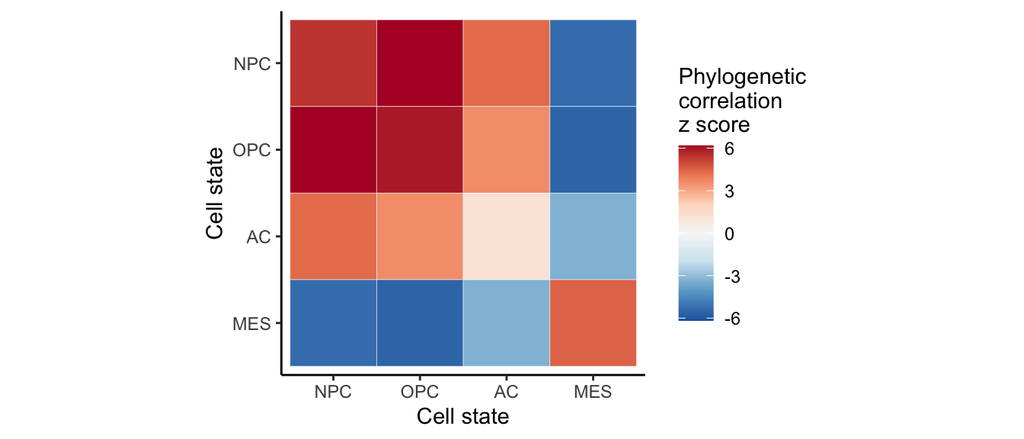

```r
# Plot phylogenetic correlation heat map.
df %>%
  ggplot(aes(x=Var1, y=Var2, fill=Z)) +
  geom_tile(col="white") +
  scale_fill_distiller(palette = 5, type = "div",
                       limits=c(-maxz,maxz)) +
  theme_classic() +
  scale_y_discrete(limits=rev) +
  labs(fill="Phylogenetic\ncorrelation\nz score") +
  xlab("Cell state") + ylab("Cell state") +
  theme(aspect.ratio = 1)
```

#### Cell state transition probabilities

Beyond measuring phylogenetic correlations, the PATH framework can be applied to infer unobserved cell state transition dynamics. This is achieved by converting the phylogenetic correlations of categorical cell states (or cell types) into transition probability estimates.

To use this approach on our GBM phylogeny, we first need to assign cells to distinct or categorical cell states. We might expect that a cell occupying a particular cell state will express the genes associated with that cell state more than genes associated with other cell states. Using this perspective, we can classify each of the MGH115 cells as either an NPC, OPC, AC, or MES cell based on which GBM module is expressed the highest.

Here, we count how many cells are in each of the four GBM module defined states.

```r
# Get each cell's maximum GBM module score
table(colnames(modules115)[max.col(modules115)])
```

```
#>
#>  AC MES NPC OPC
#>  15  15   5   3
```

In this sample we observe 5 NPC, 3 OPC, 15 AC, and 15 MES cells. Since both NPC and OPC cells are similar, and represent a more general “stem-like” GBM cell state, we can simplify our analysis by studying 3 cell states, by combing both NPC and OPC cells into the stem-like cell state.

As such, we classify cells into one of three distinct cell states,

- Stem-like (which includes both progenitor states NPC and OPC),
- AC-like,
- MES-like.

```r
# Combine progenitor states into the stem-like state.
states4 <- max.col(modules115)
states3 <- ifelse(states4 == 1, 2, states4) - 1

# Add categorical state data to phylogeny
tree115$states <- states3
```

We can then use the PATH function `PATH_inf()` to infer transition probabilities connecting stem-like, AC-like, and MES-like cell states.

```r
# Use PATH to infer transition probabilities between stem-like, AC, and MES cells
Pinf <- PATH_inf(tree115, impute_branches = T, sample_rate_est = 10^-6)

# Format PATH output
Ptinf.df <- data.frame(Pinf$Pt)
rownames(Ptinf.df) <- c("Stem", "AC", "MES")
```

PATH inferred transitions $\hat{P}(t=\tau)$.

|  | Stem | AC | MES |
| --- | --- | --- | --- |
| Stem | 0.4 | 0.60 | 0.00 |
| AC | 0.3 | 0.20 | 0.50 |
| MES | 0.0 | 0.56 | 0.44 |

Interestingly, the inference for this sample, shows that transitions between the stem-like cell and MES-like cell states need to pass through the AC-like state, which could suggest that the AC-like cell state functions as an intermediary.

### Discover heritable transcriptional modules

Moving beyond GBM gene modules and the inference of cell state transition dynamics, we can also use PATH to quantify the phylogenetic patterning of individual genes. We can then use these results for further analyses, as for example, to discover heritable transcriptional modules in an unbiased fashion.

Below, we use PATH to rank the expression of 3,000 genes observed in our GBM sample by their heritabilities (phylogeneticauto-correlation z scores), and use the PATH function `xcor_gsea()` (which relies on tools from the R packages *msigdbr* and *fgsea*) to search for highly heritable gene modules.

For this analysis, genes are ranked by the heritability of their expression and Gene Set Enrichment Analysis (GSEA) is used to nominate highly heritable modules.

```r
genesets = msigdbr::msigdbr(species = "Homo sapiens", subcategory = "CGP")
pathwaysH = split(x = genesets$gene_symbol, f = genesets$gs_name)
pathwaysH <- lapply(pathwaysH, unique)
pathwaysH <- c(pathwaysH, as.list(neftel.genes))
```

```r
xcgsea <- xcor_gsea(genes115, Winv, pathwaysH, ncores = 1)
```

```
#> Warning in preparePathwaysAndStats(pathways, stats, minSize, maxSize, gseaParam, : There are ties in the preranked stats (0.07% of the list).
#> The order of those tied genes will be arbitrary, which may produce unexpected results.
```

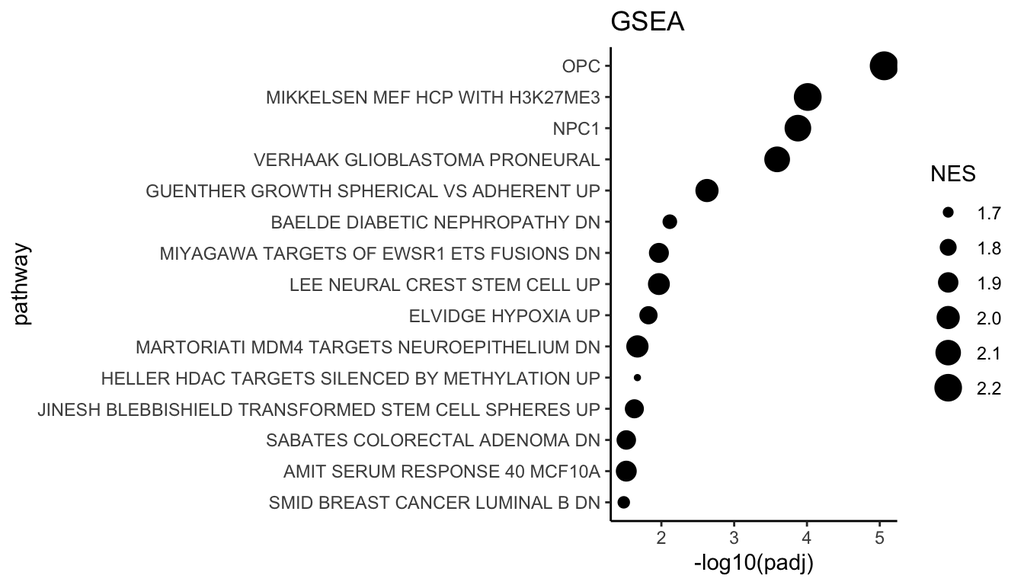

```r
 xcgsea %>% as_tibble() %>%
   arrange(desc(-padj)) %>%
   mutate(rank=rank(padj)) %>%
   filter(padj < 0.05 & rank <= 15) %>%
   mutate(pathway=gsub("_", " ", pathway)) %>%
   ggplot(aes(x=reorder(pathway, -padj, min), y=-log10(padj) )) +
   geom_point(aes(size=NES)
   ) + xlab("pathway") + coord_flip() +
   ggtitle("GSEA") +
   theme_classic()
```

Results from this analysis reveal some gene sets enriched among heritable genes in this sample, including sets associated with GBM and other biological processes.